# About

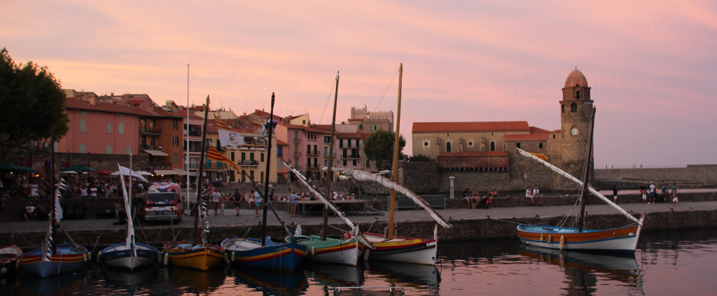

pretty picture, all rights reserved

## About me

My name is Marie Beigelman. I am a second-year PhD candidate in Economics at the University of Barcelona supervised by UB Professor [Judit Vall Castello](https://www.juditvall.com/).

I am an applied economist working on Public Economics questions, with a special interest in gender inequality, health, and intra-familiar violence. For the first chapter of my thesis, I have been investigating the impact of the COVID-19 pandemic on intimate partner violence in Spain. I am currently working on the persistence of intra-familiar violence and its effects on the health of descendants.

You can find out more about my research [here](https://mariebeigelman.github.io/research).

I was born and grew up in France, where I studied Statistical Engineering in the “Grande Ecole” *ENSAE Paristech*. I also hold a Master in Public Policy and Development from the *Paris School of Economics*. Before starting my PhD I worked for two years as a statistician-economist specialized in socioeconomics studies for professional unions in the health sector.

## News

- See our new WB on the **effect of COVID-19 on help-seeking behavior for intimate partner violence victims** - more on this to come! (click [here](https://mariebeigelman.github.io/files/paper1_COVID19.pdf) for the latest version)
- Happy to be presenting this paper (and ongoing research) at the **[European Society for Population Economics](https://www.espe.org/)** in June 2021, hosted by the University of Barcelona and the BGSE